# Homework 04 - Wrangling Spatial Data

Daniel Kwik

### Load packages and data

```r
library(tidyverse)
```

```r
dennys <- read_rds("data/dennys.rds")
laquinta <- read_rds("data/laquinta.rds")
states <- read_csv("data/states.csv", col_types = cols(
  name = col_character(),
  abbreviation = col_character(),
  area = col_double()
))
```

### Exercise 1

```r
dn_ak <- dennys %>%
  filter(state == "AK")
nrow(dn_ak)
```

```
## [1] 3
```

There are 3 Denny’s locations in Alaska

### Exercise 2

```r
lq_ak <- laquinta %>%
  filter(state == "AK")
nrow(lq_ak)
```

```
## [1] 2
```

There are 2 Laquinta locations in Alaska.

### Exercise 3

There are 6 possible combinations between Denny’s and Laquinta locations.

### Exercise 4

```r
dn_lq_ak <- full_join(dn_ak, lq_ak, by = "state", suffix = c("_dn", "_lq"))
dn_lq_ak
```

```
## # A tibble: 6 x 11
##   address_dn  city_dn  state zip_dn longitude_dn latitude_dn address_lq  city_lq
##   <chr>       <chr>    <chr> <chr>         <dbl>       <dbl> <chr>       <chr>
## 1 2900 Denali Anchora… AK    99503         -150.        61.2 3501 Minne… "\nAnc…
## 2 2900 Denali Anchora… AK    99503         -150.        61.2 4920 Dale … "\nFai…
## 3 3850 Debar… Anchora… AK    99508         -150.        61.2 3501 Minne… "\nAnc…
## 4 3850 Debar… Anchora… AK    99508         -150.        61.2 4920 Dale … "\nFai…
## 5 1929 Airpo… Fairban… AK    99701         -148.        64.8 3501 Minne… "\nAnc…
## 6 1929 Airpo… Fairban… AK    99701         -148.        64.8 4920 Dale … "\nFai…
## # … with 3 more variables: zip_lq <chr>, longitude_lq <dbl>, latitude_lq <dbl>
```

There are 6 observations in this dataframe.

### Exercise 5

```r
# Implementation from dsbox
haversine <- function(long1, lat1, long2, lat2) {
  # convert to radians
  long1 = long1 * pi / 180
  lat1  = lat1  * pi / 180
  long2 = long2 * pi / 180
  lat2  = lat2  * pi / 180

  # Earth mean radius in km (WGS84 ellipsoid)
  R = 6371.009

  a = sin((lat2 - lat1)/2)^2 + cos(lat1) * cos(lat2) * sin((long2 - long1)/2)^2
  d = R * 2 * asin(sqrt(a))
  # Return the distance in km
  d
}


dn_lq_ak <- dn_lq_ak %>%
  mutate(distance = haversine(longitude_dn, latitude_dn, longitude_lq, latitude_lq))
dn_lq_ak
```

```
## # A tibble: 6 x 12
##   address_dn  city_dn  state zip_dn longitude_dn latitude_dn address_lq  city_lq
##   <chr>       <chr>    <chr> <chr>         <dbl>       <dbl> <chr>       <chr>
## 1 2900 Denali Anchora… AK    99503         -150.        61.2 3501 Minne… "\nAnc…
## 2 2900 Denali Anchora… AK    99503         -150.        61.2 4920 Dale … "\nFai…
## 3 3850 Debar… Anchora… AK    99508         -150.        61.2 3501 Minne… "\nAnc…
## 4 3850 Debar… Anchora… AK    99508         -150.        61.2 4920 Dale … "\nFai…
## 5 1929 Airpo… Fairban… AK    99701         -148.        64.8 3501 Minne… "\nAnc…
## 6 1929 Airpo… Fairban… AK    99701         -148.        64.8 4920 Dale … "\nFai…
## # … with 4 more variables: zip_lq <chr>, longitude_lq <dbl>, latitude_lq <dbl>,
## #   distance <dbl>
```

### Exercise 6

```r
laquinta_to_dennys <- dn_lq_ak %>%
  group_by(address_lq) %>%
  summarize(count = n(), dist_to_nearest = min(distance))
```

### Exercise 7

There are Denny’s locations 2.03km away from the Minnesota Dr. location, and a Denny’s location 5.20km away from the Dale Rd location.

### Exercise 8

```r
compute_closest_dennys <- function(the_state) {
  dn_state <- dennys %>%
    filter(state == the_state)
  lq_state <- laquinta %>%
    filter(state == the_state)

  # join to get all possible pairings
  dist_to_closest <- full_join(dn_state, lq_state, by = "state", suffix = c("_dn", "_lq")) %>%
    mutate(distance = haversine(longitude_dn, latitude_dn, longitude_lq, latitude_lq)) %>%
  # compute distances
    group_by(address_lq) %>%
  # compute distance to closest Denny's for each La Quinta location.
    summarize(dist_to_nearest = (min(round(distance, 2)))) %>%
    arrange(dist_to_nearest)

  return(dist_to_closest)
}
```

### Exercise 9

```r
NC<-compute_closest_dennys("NC")
NC
```

```
## # A tibble: 12 x 2
##    address_lq                   dist_to_nearest
##    <chr>                                  <dbl>
##  1 4900 South Tryon St                     1.78
##  2 2211 Summit Park Ln                     5.04
##  3 4414 Durham Chapel Hill Blvd            5.06
##  4 1910 Westpark Dr                        6.3
##  5 3127 Sloan Dr                           9.17
##  6 191 Crescent Commons                   11.9
##  7 1001 Hospitality Ct                    14.5
##  8 1001 Aerial Center Pkwy                14.6
##  9 1201 Lanada Rd                         19.1
## 10 2020 Griffith Rd                       20.1
## 11 1607 Fairgrove Church Rd               38.5
## 12 165 Hwy 105 Extension                  55.4
```

```r
compute_closest_dennys("NC") %>%
  summarize(min(dist_to_nearest), round(median(dist_to_nearest), 2))
```

```
## # A tibble: 1 x 2
##   `min(dist_to_nearest)` `round(median(dist_to_nearest), 2)`
##                    <dbl>                               <dbl>
## 1                   1.78                                13.2
```

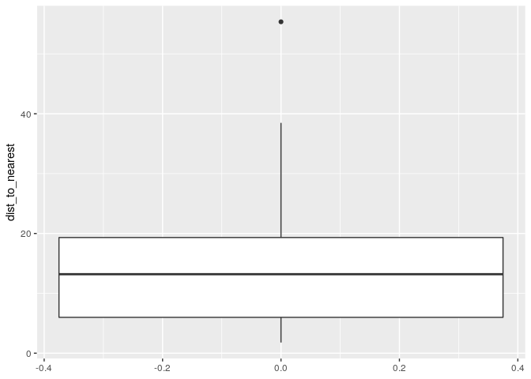

```r
ggplot(NC)+
  geom_boxplot(aes(y = dist_to_nearest))
```

### Exercise 10

```r
TX <- compute_closest_dennys("TX")
TX
```

```
## # A tibble: 237 x 2
##    address_lq               dist_to_nearest
##    <chr>                              <dbl>
##  1 601 Ave Q                           0.02
##  2 1402 Seawall Blvd                   0.03
##  3 3610 Santa Ursula Ave               0.03
##  4 7625 East Ben White Blvd            0.03
##  5 1112 South Fort Hood St             0.04
##  6 28673 I-45 North                    0.04
##  7 11033 Gateway Blvd West             0.06
##  8 2950 Wood Ridge Blvd                0.06
##  9 4105 West Airport Fwy               0.06
## 10 1708 Interstate 40 East             0.07
## # … with 227 more rows
```

```r
compute_closest_dennys("TX") %>%
  summarize(min(dist_to_nearest), round(median(dist_to_nearest), 2))
```

```
## # A tibble: 1 x 2
##   `min(dist_to_nearest)` `round(median(dist_to_nearest), 2)`
##                    <dbl>                               <dbl>
## 1                   0.02                                5.03
```

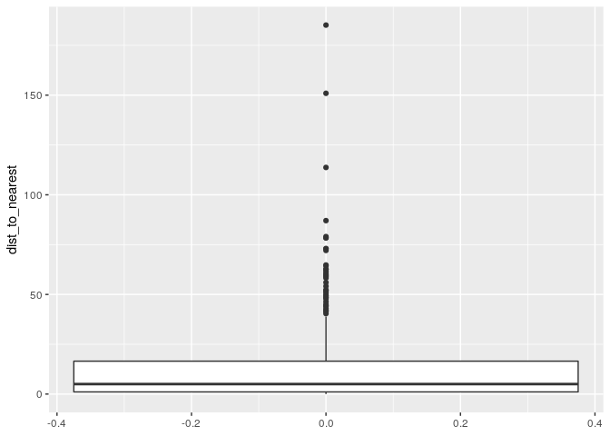

```r
ggplot(TX)+
  geom_boxplot(aes(y = dist_to_nearest))
```

### Exercise 11

```r
MI <- compute_closest_dennys("MI")
MI
```

```
## # A tibble: 4 x 2
##   address_lq     dist_to_nearest
##   <chr>                    <dbl>
## 1 12888 Reeck Rd            1.84
## 2 45311 Park Ave            1.99
## 3 30847 Flynn Dr           10.1
## 4 41211 Ford Rd            14.2
```

```r
compute_closest_dennys("MI") %>%
  summarize(min(dist_to_nearest), round(median(dist_to_nearest), 2))
```

```
## # A tibble: 1 x 2
##   `min(dist_to_nearest)` `round(median(dist_to_nearest), 2)`
##                    <dbl>                               <dbl>
## 1                   1.84                                6.04
```

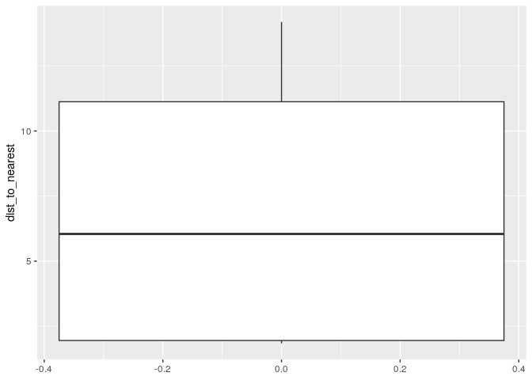

```r
ggplot(MI)+
  geom_boxplot(aes(y = dist_to_nearest))
```

## Wrap-Up

Among the states I examined (NC, TX, MI), Mitch Hedberg’s joke is most likely to hold true in Texas. This is because the min and median distances to the nearest dennys are lower than that in NC and MI.

### GitHub permalink

https://github.com/Calvin-DS202-21FA/portfolio-dkwik/blob/69c3e3b915df16be565cd7885314b442056c19d1/hw/hw04-wrangle-spatial/hw04-wrangle-spatial.Rmd

### Partners

nil

### Reflections

-Assignment was quite straightforward and was helpful. It took me about 1.5 hours to complete and I didn’t get stuck in too many places. I needed to learn how to use the function as well as how to round numbers in this exercise. In exercise 9’s sample results in the assignment page, I did not know how to get the city_lq column to show on the dataframe, but it did not seem that important either. Overall, I thought the assignment was clear and instructions were ample.